# Homework 2

Beatriz Wahle

2024-09-19

**Dear AABC Team,**

I have been notified of you current worries regarding the construction of a bridge on the Huron River in Ann Arbor. I understand that the bridge will need a strength of 40 for anticipated traffic load and there are different options to try and reach that goal.

#### 1. Get the data

Firstly, I need to upload the dataset I will be working with in order to train and test the prediction model. Furthermore, I will be printing its summary and structure, to have an overall understanding of the columns we will be working with.

```r
library(caret)
data <- read.csv("concrete.csv")
summary(data)
```

```
##      cement           slag            ash             water
##  Min.   :102.0   Min.   :  0.0   Min.   :  0.00   Min.   :121.8
##  1st Qu.:192.4   1st Qu.:  0.0   1st Qu.:  0.00   1st Qu.:164.9
##  Median :272.9   Median : 22.0   Median :  0.00   Median :185.0
##  Mean   :281.2   Mean   : 73.9   Mean   : 54.19   Mean   :181.6
##  3rd Qu.:350.0   3rd Qu.:142.9   3rd Qu.:118.30   3rd Qu.:192.0
##  Max.   :540.0   Max.   :359.4   Max.   :200.10   Max.   :247.0
##   superplastic      coarseagg         fineagg           age
##  Min.   : 0.000   Min.   : 801.0   Min.   :594.0   Min.   :  1.00
##  1st Qu.: 0.000   1st Qu.: 932.0   1st Qu.:731.0   1st Qu.:  7.00
##  Median : 6.400   Median : 968.0   Median :779.5   Median : 28.00
##  Mean   : 6.205   Mean   : 972.9   Mean   :773.6   Mean   : 45.66
##  3rd Qu.:10.200   3rd Qu.:1029.4   3rd Qu.:824.0   3rd Qu.: 56.00
##  Max.   :32.200   Max.   :1145.0   Max.   :992.6   Max.   :365.00
##     strength
##  Min.   : 2.33
##  1st Qu.:23.71
##  Median :34.45
##  Mean   :35.82
##  3rd Qu.:46.13
##  Max.   :82.60
```

```r
str(data)
```

```
## 'data.frame':    1030 obs. of  9 variables:
##  $ cement      : num  141 169 250 266 155 ...
##  $ slag        : num  212 42.2 0 114 183.4 ...
##  $ ash         : num  0 124.3 95.7 0 0 ...
##  $ water       : num  204 158 187 228 193 ...
##  $ superplastic: num  0 10.8 5.5 0 9.1 0 0 6.4 0 9 ...
##  $ coarseagg   : num  972 1081 957 932 1047 ...
##  $ fineagg     : num  748 796 861 670 697 ...
##  $ age         : int  28 14 28 28 28 90 7 56 28 28 ...
##  $ strength    : num  29.9 23.5 29.2 45.9 18.3 ...
```

#### 2. Clean the data

In this next step, we need to prepare the data for the future analysis. This involves both checking for missing values and evaluating if the columns offer the data in a format that makes sense for the prediction.

From the summary and the structure of the data there are already a couple important things to note. Firstly, there are apparently no missing values in the dataset (as we can see that all the statistical values appear to be normal for all variables). Secondly, we can see that most columns are numeric, with exception to `age` that is in integer form. None of the variables should be converted into factors as they are measured in units and have continuous numerical relationships with concrete strength. Treating them as continuous makes sense because their values can vary in a meaningful way, and the model will benefit from capturing that variation.

If we want a second assurance that there are no missing values, here is a function to count the missing values per column:

```r
colSums(is.na(data))
```

```
##       cement         slag          ash        water superplastic    coarseagg
##            0            0            0            0            0            0
##      fineagg          age     strength
##            0            0            0
```

As we can see there are no missing values.

#### 3. Split the data

With no need to deal with missing values or column transformations, we are ready to move on to step 3. Splitting data before building a prediction model is essential to evaluate the model’s performance on unseen data. The training set is used to train the model, while the test set is used to assess how well the model generalizes to new data. This ensures that the model isn’t overfitting (performing well only on the training data but poorly on new data) and provides an unbiased evaluation of its predictive performance.

```r
train_rate <- 0.8 #this means that 80% of the dataset will be on the training set
set.seed(0) # this ensures that the same random split to occur each time, which makes model results consistent and comparable across runs
train_rows <- sample(1:nrow(data), train_rate * nrow(data)) #separate the rows for training

data_train <- data[train_rows, ] # get the set from those rows
data_test <- data[-train_rows, ] # set except those rows
```

#### 4. Building the model

The idea here is to build the most complete model we can, interaction-heavy model with polynomial terms. After building the complex model, the step function performs backward elimination. This method iteratively removes the least significant variables based on the AIC to reduce the model’s complexity while retaining important predictors. It’s a common method to avoid overfitting while keeping the model’s predictive power.

```r
GiantModel <- lm(strength ~ . + .*.  + I(cement^2) + I(slag^2) + I(ash^2) + I(water^2) + I(superplastic^2) + I(coarseagg^2) + I(fineagg^2) + I(age^2), data = data_train)
summary(GiantModel)
```

```
##
## Call:
## lm(formula = strength ~ . + . * . + I(cement^2) + I(slag^2) +
##     I(ash^2) + I(water^2) + I(superplastic^2) + I(coarseagg^2) +
##     I(fineagg^2) + I(age^2), data = data_train)
##
## Residuals:
##      Min       1Q   Median       3Q      Max
## -26.0053  -4.5605  -0.1088   4.6781  26.2124
##
## Coefficients:
##                          Estimate Std. Error t value Pr(>|t|)
## (Intercept)            -4.462e+03  1.308e+03  -3.411 0.000682 ***
## cement                  2.638e+00  8.116e-01   3.250 0.001204 **
## slag                    2.078e+00  9.417e-01   2.207 0.027593 *
## ash                     1.766e+00  1.122e+00   1.573 0.116014
## water                   1.413e+01  2.980e+00   4.740 2.54e-06 ***
## superplastic            2.965e+01  8.436e+00   3.514 0.000466 ***
## coarseagg               2.609e+00  9.829e-01   2.654 0.008110 **
## fineagg                 3.485e+00  1.098e+00   3.173 0.001567 **
## age                     1.652e-01  4.728e-01   0.349 0.726884
## I(cement^2)            -3.818e-04  1.374e-04  -2.778 0.005599 **
## I(slag^2)              -2.435e-04  1.976e-04  -1.232 0.218264
## I(ash^2)               -5.390e-05  3.296e-04  -0.164 0.870126
## I(water^2)             -8.903e-03  1.946e-03  -4.575 5.55e-06 ***
## I(superplastic^2)      -4.567e-02  1.722e-02  -2.652 0.008171 **
## I(coarseagg^2)         -3.315e-04  1.916e-04  -1.730 0.083989 .
## I(fineagg^2)           -7.549e-04  2.361e-04  -3.197 0.001443 **
## I(age^2)               -6.098e-04  4.494e-05 -13.569  < 2e-16 ***
## cement:slag            -5.674e-04  3.213e-04  -1.766 0.077768 .
## cement:ash             -3.404e-04  3.806e-04  -0.895 0.371318
## cement:water           -4.638e-03  8.712e-04  -5.323 1.33e-07 ***
## cement:superplastic    -9.979e-03  2.392e-03  -4.172 3.37e-05 ***
## cement:coarseagg       -6.564e-04  3.098e-04  -2.119 0.034427 *
## cement:fineagg         -9.178e-04  3.417e-04  -2.686 0.007392 **
## cement:age              1.631e-04  1.843e-04   0.885 0.376604
## slag:ash               -6.383e-05  4.622e-04  -0.138 0.890203
## slag:water             -3.723e-03  1.128e-03  -3.301 0.001008 **
## slag:superplastic      -8.535e-03  2.918e-03  -2.925 0.003543 **
## slag:coarseagg         -5.822e-04  3.449e-04  -1.688 0.091834 .
```

[output cut: 8 more lines]

```
## water:coarseagg        -5.016e-03  1.105e-03  -4.538 6.58e-06 ***
## water:fineagg          -5.381e-03  1.264e-03  -4.259 2.31e-05 ***
## water:age              -4.068e-04  8.111e-04  -0.502 0.616096
## superplastic:coarseagg -9.487e-03  3.151e-03  -3.011 0.002687 **
## superplastic:fineagg   -1.167e-02  3.214e-03  -3.633 0.000298 ***
## superplastic:age        3.171e-03  2.408e-03   1.317 0.188283
## coarseagg:fineagg      -9.649e-04  4.015e-04  -2.403 0.016497 *
## coarseagg:age          -2.796e-05  1.439e-04  -0.194 0.845946
## fineagg:age             1.918e-04  2.067e-04   0.928 0.353742
## ---
## Signif. codes:  0 '***' 0.001 '**' 0.01 '*' 0.05 '.' 0.1 ' ' 1
##
## Residual standard error: 7.453 on 779 degrees of freedom
## Multiple R-squared:  0.8068, Adjusted R-squared:  0.7959
## F-statistic: 73.93 on 44 and 779 DF,  p-value: < 2.2e-16
```

```r
stepmodel1 <- step(GiantModel, direction = 'backward', trace = T)
```

```
## Start:  AIC=3353.96
## strength ~ cement + slag + ash + water + superplastic + coarseagg +
##     fineagg + age + (cement + slag + ash + water + superplastic +
##     coarseagg + fineagg + age) * (cement + slag + ash + water +
##     superplastic + coarseagg + fineagg + age) + I(cement^2) +
##     I(slag^2) + I(ash^2) + I(water^2) + I(superplastic^2) + I(coarseagg^2) +
##     I(fineagg^2) + I(age^2)
##
##                          Df Sum of Sq   RSS    AIC
## - slag:ash                1       1.1 43274 3352.0
## - I(ash^2)                1       1.5 43274 3352.0
## - coarseagg:age           1       2.1 43275 3352.0
## - water:age               1      14.0 43287 3352.2
## - cement:age              1      43.5 43316 3352.8
## - ash:coarseagg           1      44.2 43317 3352.8
## - cement:ash              1      44.4 43317 3352.8
## - fineagg:age             1      47.8 43321 3352.9
## - ash:fineagg             1      58.6 43332 3353.1
## - I(slag^2)               1      84.3 43357 3353.6
## - superplastic:age        1      96.3 43369 3353.8
## <none>                                43273 3354.0
## - slag:fineagg            1     148.8 43422 3354.8
## - slag:coarseagg          1     158.3 43431 3355.0
## - I(coarseagg^2)          1     166.3 43439 3355.1
## - cement:slag             1     173.3 43446 3355.2
## - slag:age                1     239.3 43512 3356.5
## - cement:coarseagg        1     249.4 43522 3356.7
## - ash:age                 1     295.2 43568 3357.6
## - coarseagg:fineagg       1     320.7 43594 3358.0
## - I(superplastic^2)       1     390.6 43664 3359.4
## - cement:fineagg          1     400.7 43674 3359.6
## - I(cement^2)             1     428.7 43702 3360.1
## - water:superplastic      1     441.1 43714 3360.3
## - slag:superplastic       1     475.3 43748 3361.0
## - superplastic:coarseagg  1     503.6 43777 3361.5
## - I(fineagg^2)            1     567.9 43841 3362.7
## - slag:water              1     605.3 43878 3363.4
## - ash:water               1     611.0 43884 3363.5
## - superplastic:fineagg    1     733.2 44006 3365.8
## - ash:superplastic        1     880.7 44154 3368.6
```

[output cut: 185 more lines]

```
## - ash:age                 1     642.9 43938 3356.5
## - superplastic:fineagg    1     720.4 44016 3358.0
## - ash:superplastic        1     898.5 44194 3361.3
## - cement:fineagg          1     941.2 44236 3362.1
## - cement:superplastic     1     987.6 44283 3363.0
## - I(cement^2)             1     988.3 44283 3363.0
## - I(fineagg^2)            1     998.2 44293 3363.2
## - cement:slag             1    1018.1 44313 3363.5
## - ash:water               1    1076.6 44372 3364.6
## - slag:water              1    1133.7 44429 3365.7
## - I(water^2)              1    1362.9 44658 3369.9
## - water:fineagg           1    1502.3 44798 3372.5
## - water:coarseagg         1    1674.3 44969 3375.6
## - cement:water            1    2534.5 45830 3391.3
## - I(age^2)                1   10511.2 53806 3523.5
```

```r
summary(stepmodel1)
```

```
##
## Call:
## lm(formula = strength ~ cement + slag + ash + water + superplastic +
##     coarseagg + fineagg + age + I(cement^2) + I(slag^2) + I(water^2) +
##     I(superplastic^2) + I(coarseagg^2) + I(fineagg^2) + I(age^2) +
##     cement:slag + cement:ash + cement:water + cement:superplastic +
##     cement:coarseagg + cement:fineagg + cement:age + slag:water +
##     slag:superplastic + slag:coarseagg + slag:fineagg + slag:age +
##     ash:water + ash:superplastic + ash:coarseagg + ash:fineagg +
##     ash:age + water:superplastic + water:coarseagg + water:fineagg +
##     superplastic:coarseagg + superplastic:fineagg + superplastic:age +
##     coarseagg:fineagg + fineagg:age, data = data_train)
##
## Residuals:
##      Min       1Q   Median       3Q      Max
## -26.0211  -4.5515  -0.1797   4.6382  26.2299
##
## Coefficients:
##                          Estimate Std. Error t value Pr(>|t|)
## (Intercept)            -4.321e+03  9.185e+02  -4.704 3.01e-06 ***
## cement                  2.546e+00  5.063e-01   5.029 6.13e-07 ***
## slag                    1.970e+00  4.586e-01   4.295 1.97e-05 ***
## ash                     1.611e+00  5.044e-01   3.193 0.001463 **
## water                   1.381e+01  2.393e+00   5.772 1.13e-08 ***
## superplastic            2.943e+01  8.408e+00   3.500 0.000491 ***
## coarseagg               2.510e+00  7.144e-01   3.514 0.000466 ***
## fineagg                 3.382e+00  7.798e-01   4.337 1.63e-05 ***
## age                    -4.459e-02  1.322e-01  -0.337 0.736038
## I(cement^2)            -3.661e-04  8.660e-05  -4.228 2.64e-05 ***
## I(slag^2)              -2.235e-04  7.348e-05  -3.041 0.002435 **
## I(water^2)             -8.735e-03  1.759e-03  -4.965 8.45e-07 ***
## I(superplastic^2)      -4.488e-02  1.705e-02  -2.632 0.008656 **
## I(coarseagg^2)         -3.137e-04  1.465e-04  -2.141 0.032602 *
## I(fineagg^2)           -7.379e-04  1.737e-04  -4.249 2.41e-05 ***
## I(age^2)               -6.125e-04  4.442e-05 -13.788  < 2e-16 ***
## cement:slag            -5.280e-04  1.231e-04  -4.291 2.00e-05 ***
## cement:ash             -2.824e-04  1.326e-04  -2.130 0.033512 *
## cement:water           -4.552e-03  6.724e-04  -6.770 2.52e-11 ***
## cement:superplastic    -1.001e-02  2.369e-03  -4.226 2.66e-05 ***
## cement:coarseagg       -6.202e-04  2.016e-04  -3.076 0.002172 **
```

[output cut: 11 more lines]

```
## ash:age                 8.544e-04  2.505e-04   3.410 0.000683 ***
## water:superplastic     -3.411e-02  1.220e-02  -2.797 0.005291 **
## water:coarseagg        -4.916e-03  8.934e-04  -5.503 5.07e-08 ***
## water:fineagg          -5.255e-03  1.008e-03  -5.213 2.39e-07 ***
## superplastic:coarseagg -9.465e-03  3.141e-03  -3.014 0.002665 **
## superplastic:fineagg   -1.155e-02  3.199e-03  -3.610 0.000326 ***
## superplastic:age        3.319e-03  2.099e-03   1.581 0.114310
## coarseagg:fineagg      -9.281e-04  2.923e-04  -3.175 0.001555 **
## fineagg:age             2.891e-04  1.092e-04   2.648 0.008265 **
## ---
## Signif. codes:  0 '***' 0.001 '**' 0.01 '*' 0.05 '.' 0.1 ' ' 1
##
## Residual standard error: 7.436 on 783 degrees of freedom
## Multiple R-squared:  0.8067, Adjusted R-squared:  0.7968
## F-statistic: 81.69 on 40 and 783 DF,  p-value: < 2.2e-16
```

#### 5. Prediction

Once the models are built, the trained model is applied to new, unseen data to estimate the target variable. In this case, after training the `GiantModel` and `stepmodel1` models on a set of known data, the prediction step uses the relationships learned during training to predict concrete strength for the test dataset. This step is critical because it assesses how well the model generalizes to new data and provides a measure of its real-world performance. By comparing the predicted values from the models to the actual outcomes in the test set, you can evaluate which model is more accurate and reliable for future use.

```r
giantmodel_prediction <- predict(GiantModel, data_test)
summary(giantmodel_prediction)
```

```
##    Min. 1st Qu.  Median    Mean 3rd Qu.    Max.
##   8.043  24.963  33.878  36.373  46.142  78.461
```

```r
stepmodel1_prediction <- predict(stepmodel1, data_test)
summary(stepmodel1_prediction)
```

```
##    Min. 1st Qu.  Median    Mean 3rd Qu.    Max.
##   8.049  24.954  33.956  36.386  46.210  77.463
```

#### 6. Evalute Model

This step is used to evaluate the performance of the GiantModel and stepmodel1 by comparing their predicted concrete strength values to the actual values from the test set. It calculates key metrics like R², which measures how well the model explains the variance in the data, RMSE (Root Mean Squared Error), which indicates the average error in the model’s predictions, and MAE (Mean Absolute Error), which shows the average magnitude of errors. These metrics help determine how accurately each model predicts concrete strength and allows you to compare the two models to identify which performs better for real-world application.

```r
postResample(giantmodel_prediction, data_test$strength)
```

```
##      RMSE  Rsquared       MAE
## 7.6011767 0.8134901 6.0560800
```

```r
postResample(stepmodel1_prediction, data_test$strength)
```

```
##      RMSE  Rsquared       MAE
## 7.5729491 0.8150656 6.0550198
```

The evaluation results show that the GiantModel performs slightly worse than the stepmodel1. The stepmodel1 has a lower RMSE (7.57 vs. 7.60) and a marginally higher R² (0.815 vs. 0.813), indicating it explains slightly more variance in concrete strength and has smaller prediction errors. The MAE is also lower for the stepmodel1 (6.055 vs. 6.056), meaning it has slightly more accurate predictions overall. Although the difference is minor, the stepmodel1 provides better predictive performance.

#### Step 7: Predict the case

With the model build, trained, and tested on a different dataset, it is time to use them of the initial intended prediction.

```r
#the bridge needs a strenght of 40
option1 <- data.frame(cement=142, age = 28, ash = 130, slag = 167, water = 175, superplastic = 11, coarseagg = 825, fineagg = 825)
option2 <- data.frame(cement=200, age = 14, ash = 130, slag = 167, water = 175, superplastic = 11, coarseagg = 825, fineagg = 825)

predict(GiantModel, option1)
```

```
##        1
## 35.22144
```

```r
predict(GiantModel, option2)
```

```
##        1
## 38.03901
```

```r
predict(stepmodel1, option1)
```

```
##        1
## 35.20868
```

```r
predict(stepmodel1, option2)
```

```
##        1
## 37.91386
```

Alternative: as you mentioned you have a lot of ash, and simply chose to use 130. My advice, would be to increase its quantity as it will have a direct impact on the strength of the bridge

```r
option3 <- data.frame(cement=200, age = 14, ash = 200, slag = 167, water = 175, superplastic = 11, coarseagg = 825, fineagg = 825)
predict(GiantModel, option3)
```

```
##        1
## 41.20103
```

```r
predict(stepmodel1, option3)
```

```
##        1
## 41.37034
```

As seen from the prediction, increasing the ash to 200 will make the bridge have the anticipated traffic load strengh needed.

### Extra

**I know that if I used the teachers seed the models would have given me predictions over fourty, but my seed gives me a better prediction model, so I just kept mine.**

Considering the relatively “low” R squared I wanted to try some other things out for my own curiosity not related to the assignment.

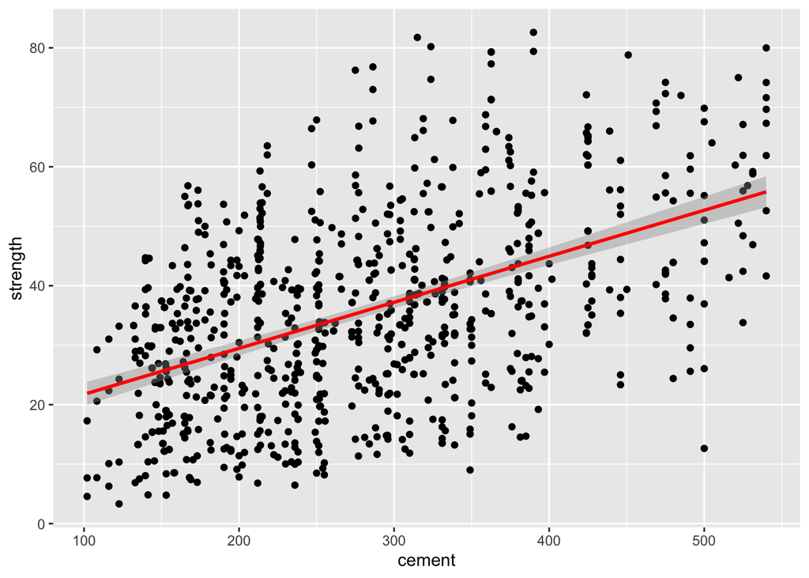

```r
# See the distribution
library(ggplot2)

ggplot(data_train, aes(x=cement, y=strength)) + geom_point() + geom_smooth(method="lm", col="red")
```

```r
# We can see there is an upwards trend, but with a lot of outliers.

#data_train$log_strength <- log(data_train$strength)
#ggplot(data_train, aes(x=cement, y=log_strength)) + geom_point() + geom_smooth(method="lm", col="red")
# Although the log transformation indeed reduce outliers, it will complicate the interpretability later on.

# There are a lot of outliers for a linar regression, there is a positive trend but explains the low evaluation
# cross-validation, ridge regression
train_control <- trainControl(method="cv", number=10)  # 10-fold cross-validation
model <- train(strength ~ . + .*. + I(cement^2) + I(slag^2) + I(ash^2) + I(water^2) + I(superplastic^2) + I(coarseagg^2) + I(fineagg^2) + I(age^2), data=data_train, method="ridge", Control=train_control)

model_prediction <- predict(model, data_test)
postResample(model_prediction, data_test$strength)
```

```
##      RMSE  Rsquared       MAE
## 7.7238648 0.8068965 6.1867432
```

```r
#the bridge needs a strenght of 40
option1 <- data.frame(cement=142, age = 28, ash = 130, slag = 167, water = 175, superplastic = 11, coarseagg = 825, fineagg = 825)
option2 <- data.frame(cement=200, age = 14, ash = 130, slag = 167, water = 175, superplastic = 11, coarseagg = 825, fineagg = 825)
option3 <- data.frame(cement=200, age = 14, ash = 200, slag = 167, water = 175, superplastic = 11, coarseagg = 825, fineagg = 825)

predict(model, option1)
```

```
## [1] 35.37319
```

```r
predict(model, option2)
```

```
## [1] 37.36261
```

```r
predict(model, option3)
```

```
## [1] 41.81405
```